# Introdução a dataviz no R

# **Positions in histograms**

Here, we’ll examine the various ways of applying positions to histograms. [**`geom_histogram()`**](http://www.rdocumentation.org/packages/ggplot2/functions/geom_histogram), a special case of [**`geom_bar()`**](http://www.rdocumentation.org/packages/ggplot2/functions/geom_bar), has a `position` argument that can take on the following values:

- `stack` (the default): Bars for different groups are stacked on top of each other.
- `dodge`: Bars for different groups are placed side by side.
- `fill`: Bars for different groups are shown as proportions.
- `identity`: Plot the values as they appear in the dataset.

Observe the difference:

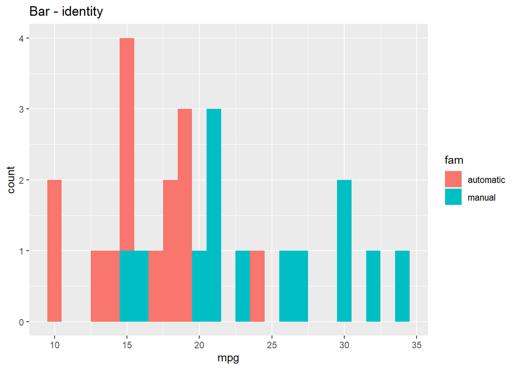

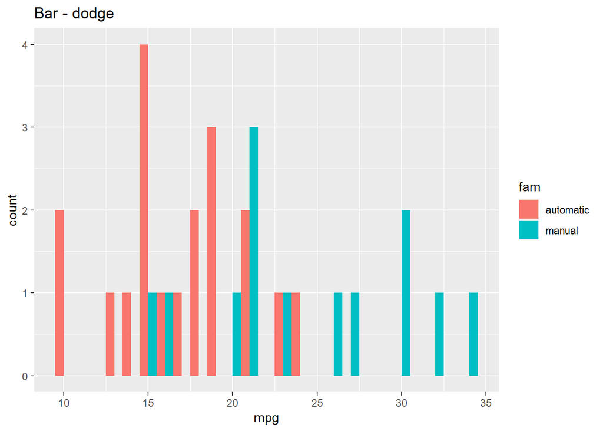

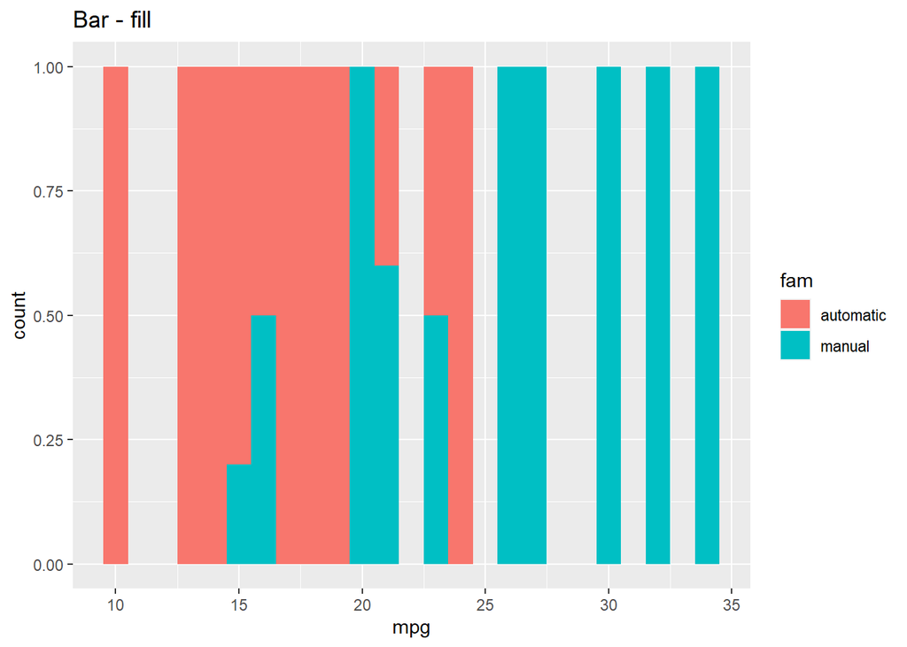

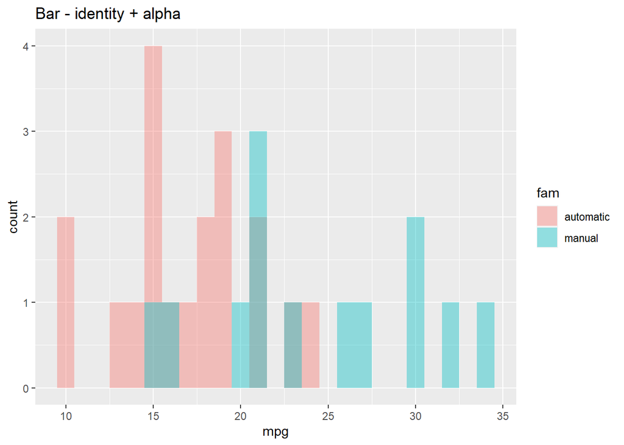

```r
par(mfrow=c(2,2))

# Update the aesthetics so the fill color is by fam
ggplot(mtcars_mod, aes(mpg, fill = fam)) +
  geom_histogram(binwidth = 1, position = "identity") +
  ggtitle('Bar - identity')

# Change the position to dodge
ggplot(mtcars_mod, aes(mpg, fill = fam)) +
  geom_histogram(binwidth = 1, position = "dodge") +
  ggtitle('Bar - dodge')

# Change the position to fill
ggplot(mtcars_mod, aes(mpg, fill = fam)) +
  geom_histogram(binwidth = 1, position = "fill") +
  ggtitle('Bar - fill')

# Change the position to identity, with transparency 0.4
ggplot(mtcars_mod, aes(mpg, fill = fam)) +
  geom_histogram(binwidth = 1, position = "identity", alpha = 0.4) +
  ggtitle('Bar - identity + alpha')

par(mfrow=c(1,1))
```

## Barplot

### **Position in bar and col plots**

Let’s see how the `position` argument changes [**`geom_bar()`**](http://www.rdocumentation.org/packages/ggplot2/functions/geom_bar).

We have three position options:

- `stack`: The default
- `dodge`: Preferred
- `fill`: To show proportions

While we will be using `geom_bar()` here, note that the function [**`geom_col()`**](http://www.rdocumentation.org/packages/ggplot2/functions/geom_col) is just `geom_bar()` where both the `position` and `stat` arguments are set to `"identity"`. It is used when we want the heights of the bars to represent the exact values in the data.

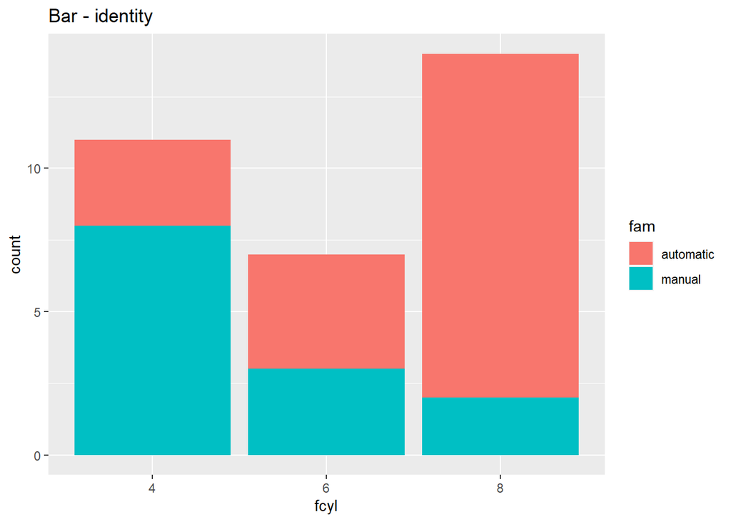

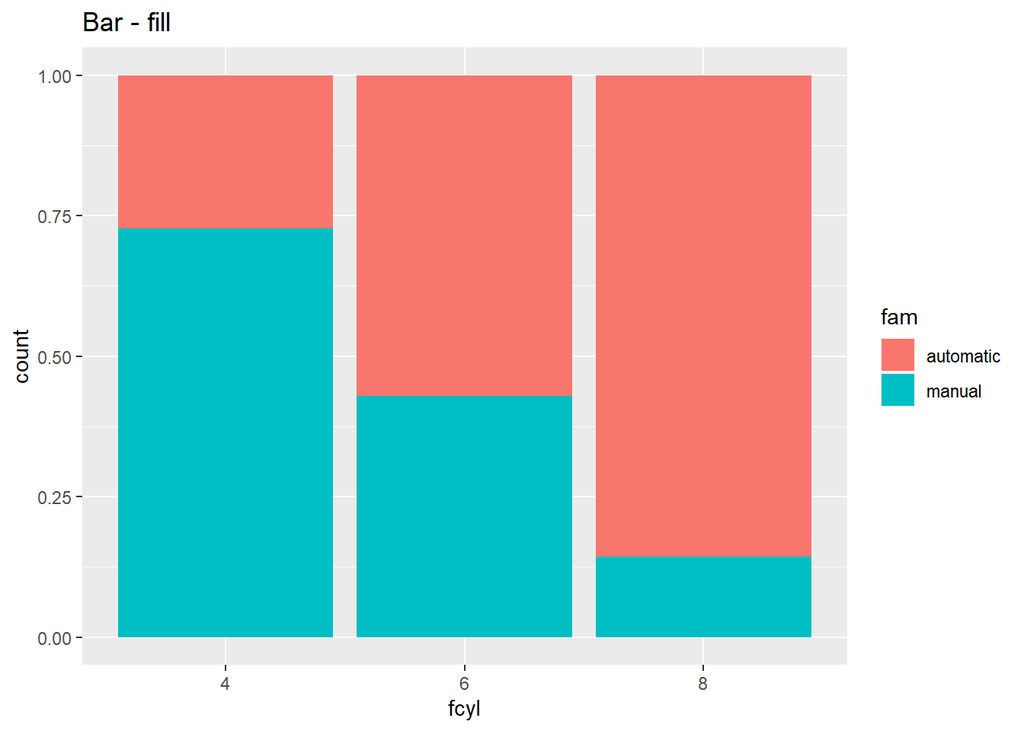

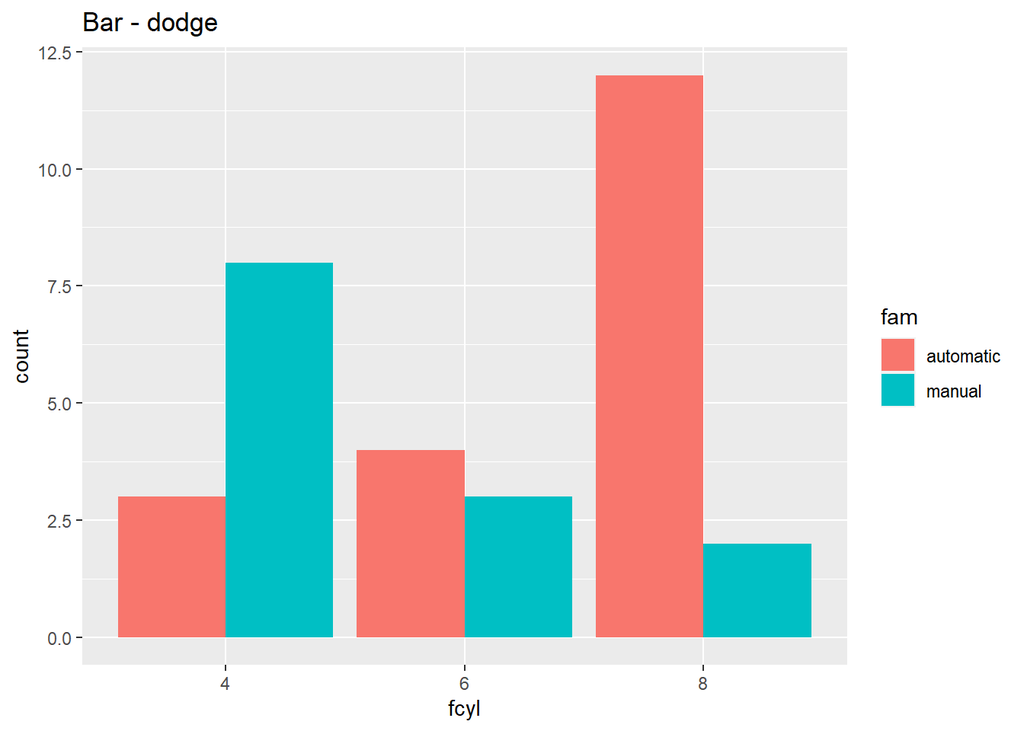

```r
par(mfrow=c(1,3))

## Plot fcyl, filled by fam - normal
ggplot(mtcars_mod, aes(x=fcyl, fill = fam)) +
  # Add a bar layer
  geom_bar() +
  ggtitle('Bar - identity')

## Plot fcyl, filled by fam - fill
ggplot(mtcars_mod, aes(fcyl, fill = fam)) +
  # Set the position to "fill"
  geom_bar(position='fill') +
  ggtitle('Bar - fill')

## Plot fcyl, filled by fam - dodge
ggplot(mtcars_mod, aes(fcyl, fill = fam)) +
  # Change the position to "dodge"
  geom_bar(position = "dodge") +
  ggtitle('Bar - dodge')
```

Bar plot with Var

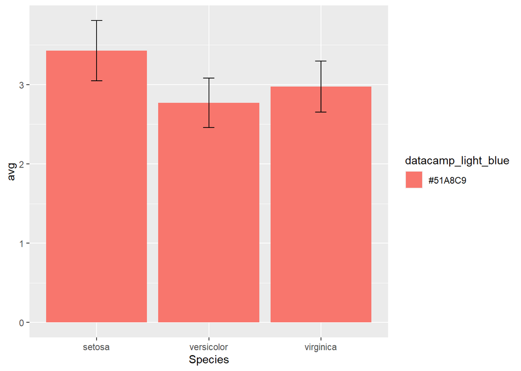

```r
# Calculate Descriptive Statistics:
iris_summ_long <-
iris %>%
  select(Species, Sepal.Width) %>%
  gather(key, value, -Species) %>%
  group_by(Species) %>%
  summarise(avg = mean(value),
            stdev = sd(value))


ggplot(iris_summ_long, aes(x = Species, y = avg, fill = datacamp_light_blue)) +
  geom_col() +
  geom_errorbar(aes(ymin = avg - stdev, ymax = avg + stdev), width = 0.1)
```

### Line Plots

Simple line graph:

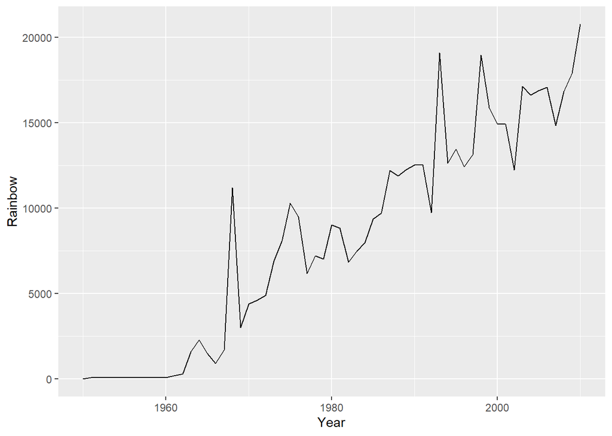

```r
link = 'https://assets.datacamp.com/production/repositories/5171/datasets/fd66a8c2408f8cccc24df8ce2668e0e195519532/fish.RData'

load(url(link))

# Ao importar os dados de um Rdata os dataset já são incorporados no drive

# Plot the Rainbow Salmon time series
ggplot(fish.species, aes(y = Rainbow, x = Year)) +
  geom_line()
```

#### Gráfico de linhas por grupos

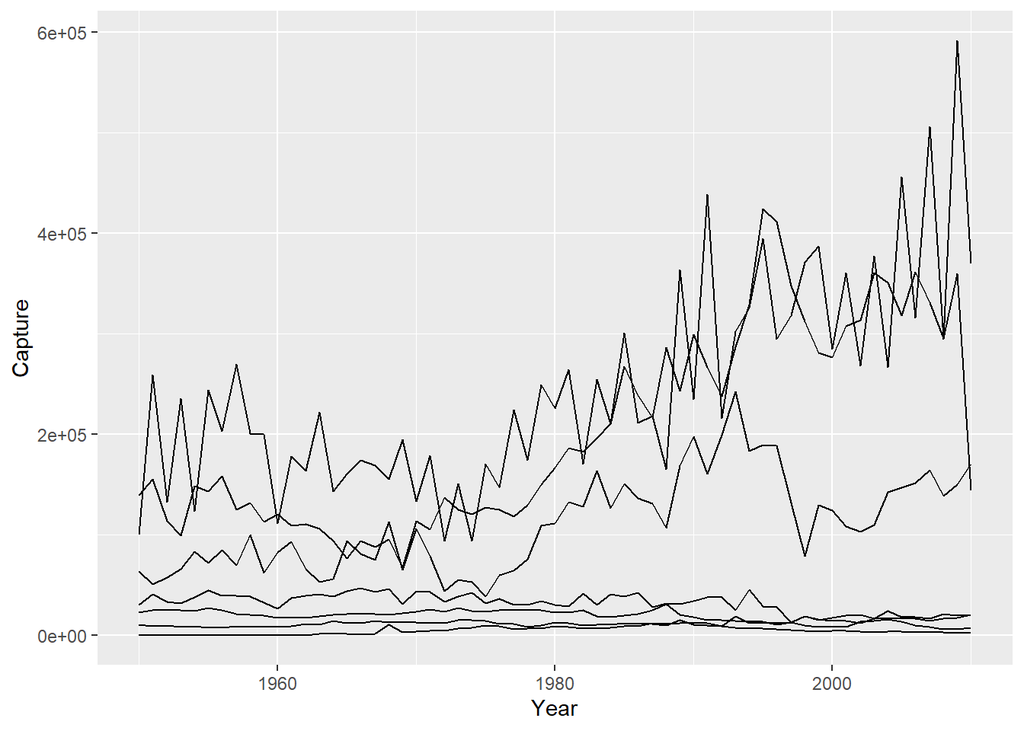

```r
# Plot multiple time-series by grouping by species
ggplot(fish.tidy, aes(x = Year, y = Capture)) +
  geom_line(aes(group = Species))
```

#### Gráfico de linhas por linetype

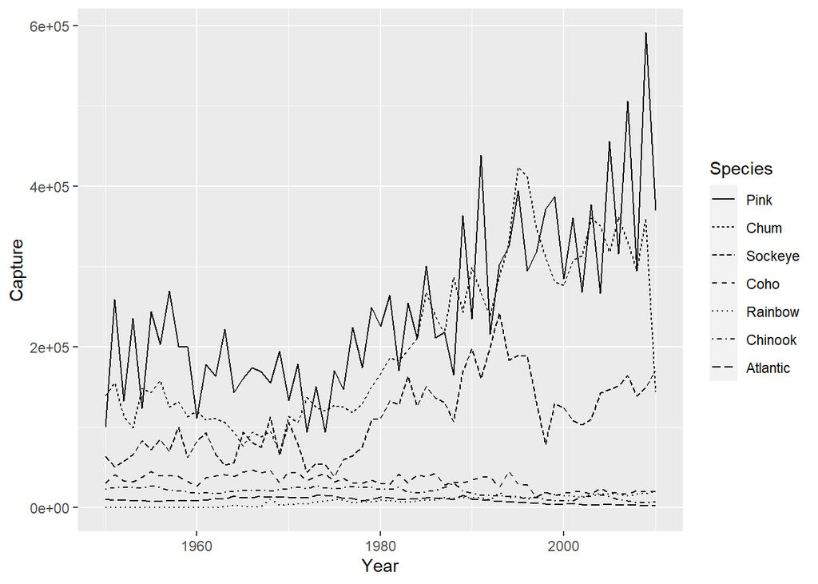

```r
ggplot(fish.tidy, aes(x = Year, y = Capture, linetype = Species)) +
  geom_line()
```

Veja que utilizando `groups` e `linetype` a visualização não ficou legal. Vamos tentar com `color`.

#### Gráfico de linhas por color

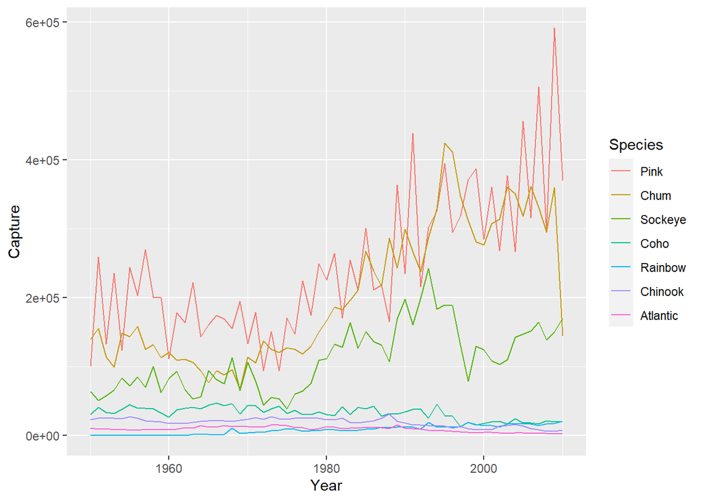

```r
# Plot multiple time-series by coloring by species
ggplot(fish.tidy, aes(x = Year, y = Capture, color = Species)) +
  geom_line()
```

#### Ribbon

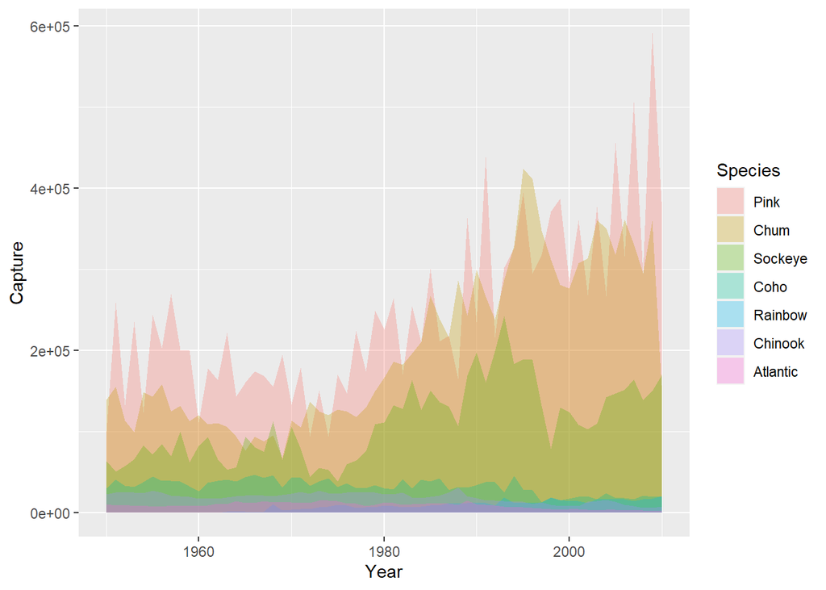

```r
ggplot(fish.tidy, aes(x = Year, y = Capture, fill = Species)) +
  geom_ribbon(aes(ymax = Capture, ymin = 0), alpha = 0.3)
```

#### Geom_areas

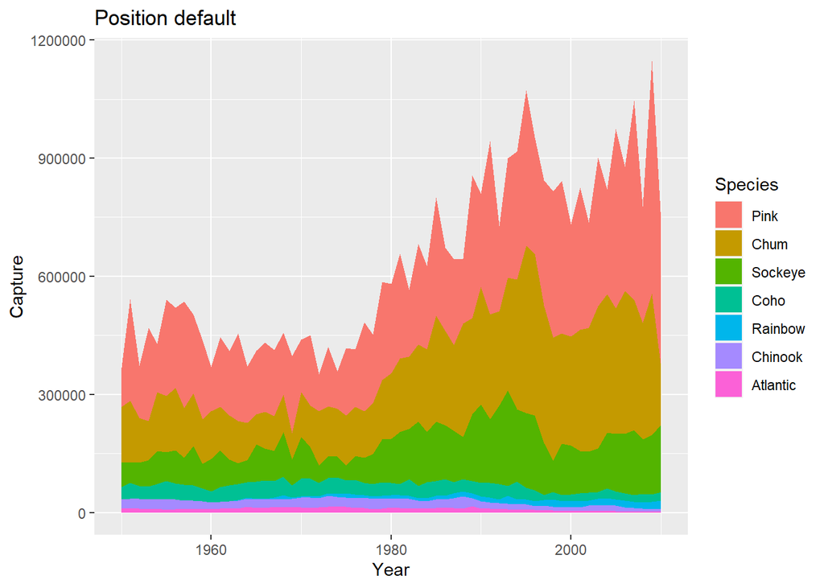

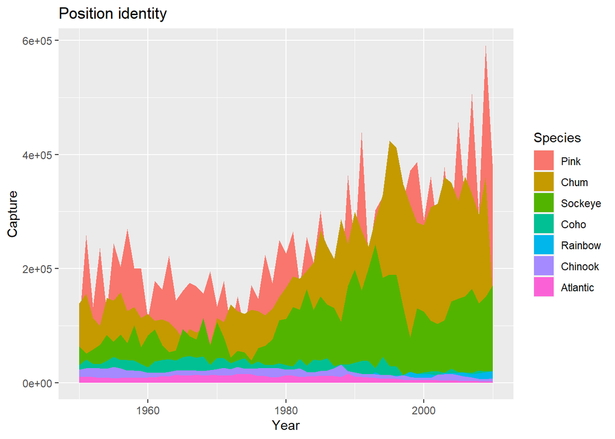

```r
par(mfrow=c(1,2))

ggplot(fish.tidy, aes(x = Year, y = Capture, fill = Species)) +
  geom_area() +
  ggtitle('Position default')

ggplot(fish.tidy, aes(x = Year, y = Capture, fill = Species)) +
  geom_area(position='identity') +
  ggtitle('Position identity')
```

Observe que sem o parâmetro de `position='identity'` os gráficos se acumulam uma em cima do outro.